# Cyclistic_Analysis

Ebubechukwu Okoye

2024-02-03

### About the Company

In 2016, Cyclistic launched a successful bike-share offering. Since then, the program has grown to a fleet of 5,824 bicycles that are geotracked and locked into a network of 692 stations across Chicago. The bikes can be unlocked from one station and returned to any other station in the system anytime.

Until now, Cyclistic’s marketing strategy relied on building general awareness and appealing to broad consumer segments. One approach that helped make these things possible was the flexibility of its pricing plans: single-ride passes, full-day passes, and annual memberships. Customers who purchase single-ride or full-day passes are referred to as casual riders. Customers who purchase annual memberships are Cyclistic members.

### Viewing the Dataset

#### Loading Packages

```r
library(tidyverse)
library(here)
library(skimr)
library(janitor)
```

#### Importing Datasets

```r
trips_2019 = read.csv("~/Cyclistic_R/Divvy_Trips_2019_Q1.csv")
trips_2020 = read.csv("~/Cyclistic_R/Divvy_Trips_2020_Q1.csv")
```

```r
#View the Datasets
head(trips_2019)
```

```
##    trip_id          start_time            end_time bikeid tripduration
## 1 21742443 2019-01-01 00:04:37 2019-01-01 00:11:07   2167        390.0
## 2 21742444 2019-01-01 00:08:13 2019-01-01 00:15:34   4386        441.0
## 3 21742445 2019-01-01 00:13:23 2019-01-01 00:27:12   1524        829.0
## 4 21742446 2019-01-01 00:13:45 2019-01-01 00:43:28    252      1,783.0
## 5 21742447 2019-01-01 00:14:52 2019-01-01 00:20:56   1170        364.0
## 6 21742448 2019-01-01 00:15:33 2019-01-01 00:19:09   2437        216.0
##   from_station_id                   from_station_name to_station_id
## 1             199              Wabash Ave & Grand Ave            84
## 2              44              State St & Randolph St           624
## 3              15                Racine Ave & 18th St           644
## 4             123      California Ave & Milwaukee Ave           176
## 5             173 Mies van der Rohe Way & Chicago Ave            35
## 6              98          LaSalle St & Washington St            49
##                  to_station_name   usertype gender birthyear
## 1      Milwaukee Ave & Grand Ave Subscriber   Male      1989
## 2 Dearborn St & Van Buren St (*) Subscriber Female      1990
## 3  Western Ave & Fillmore St (*) Subscriber Female      1994
## 4              Clark St & Elm St Subscriber   Male      1993
## 5        Streeter Dr & Grand Ave Subscriber   Male      1994
## 6        Dearborn St & Monroe St Subscriber Female      1983
```

```r
head(trips_2020)
```

```
##            ride_id rideable_type          started_at            ended_at
## 1 EACB19130B0CDA4A   docked_bike 2020-01-21 20:06:59 2020-01-21 20:14:30
## 2 8FED874C809DC021   docked_bike 2020-01-30 14:22:39 2020-01-30 14:26:22
## 3 789F3C21E472CA96   docked_bike 2020-01-09 19:29:26 2020-01-09 19:32:17
## 4 C9A388DAC6ABF313   docked_bike 2020-01-06 16:17:07 2020-01-06 16:25:56
## 5 943BC3CBECCFD662   docked_bike 2020-01-30 08:37:16 2020-01-30 08:42:48
## 6 6D9C8A6938165C11   docked_bike 2020-01-10 12:33:05 2020-01-10 12:37:54
##         start_station_name start_station_id               end_station_name
## 1 Western Ave & Leland Ave              239          Clark St & Leland Ave
## 2  Clark St & Montrose Ave              234 Southport Ave & Irving Park Rd
## 3   Broadway & Belmont Ave              296       Wilton Ave & Belmont Ave
## 4   Clark St & Randolph St               51       Fairbanks Ct & Grand Ave
## 5     Clinton St & Lake St               66          Wells St & Hubbard St
## 6    Wells St & Hubbard St              212    Desplaines St & Randolph St
##   end_station_id start_lat start_lng end_lat  end_lng member_casual
## 1            326   41.9665  -87.6884 41.9671 -87.6674        member
## 2            318   41.9616  -87.6660 41.9542 -87.6644        member
## 3            117   41.9401  -87.6455 41.9402 -87.6530        member
## 4             24   41.8846  -87.6319 41.8918 -87.6206        member
## 5            212   41.8856  -87.6418 41.8899 -87.6343        member
## 6             96   41.8899  -87.6343 41.8846 -87.6446        member
```

```r
#more on the datasets
str(trips_2019)
```

```
## 'data.frame':    365069 obs. of  12 variables:
##  $ trip_id          : int  21742443 21742444 21742445 21742446 21742447 21742448 21742449 21742450 21742451 21742452 ...
##  $ start_time       : chr  "2019-01-01 00:04:37" "2019-01-01 00:08:13" "2019-01-01 00:13:23" "2019-01-01 00:13:45" ...
##  $ end_time         : chr  "2019-01-01 00:11:07" "2019-01-01 00:15:34" "2019-01-01 00:27:12" "2019-01-01 00:43:28" ...
##  $ bikeid           : int  2167 4386 1524 252 1170 2437 2708 2796 6205 3939 ...
##  $ tripduration     : chr  "390.0" "441.0" "829.0" "1,783.0" ...
##  $ from_station_id  : int  199 44 15 123 173 98 98 211 150 268 ...
##  $ from_station_name: chr  "Wabash Ave & Grand Ave" "State St & Randolph St" "Racine Ave & 18th St" "California Ave & Milwaukee Ave" ...
##  $ to_station_id    : int  84 624 644 176 35 49 49 142 148 141 ...
##  $ to_station_name  : chr  "Milwaukee Ave & Grand Ave" "Dearborn St & Van Buren St (*)" "Western Ave & Fillmore St (*)" "Clark St & Elm St" ...
##  $ usertype         : chr  "Subscriber" "Subscriber" "Subscriber" "Subscriber" ...
##  $ gender           : chr  "Male" "Female" "Female" "Male" ...
##  $ birthyear        : int  1989 1990 1994 1993 1994 1983 1984 1990 1995 1996 ...
```

```r
str(trips_2020)
```

```
## 'data.frame':    426887 obs. of  13 variables:
##  $ ride_id           : chr  "EACB19130B0CDA4A" "8FED874C809DC021" "789F3C21E472CA96" "C9A388DAC6ABF313" ...
##  $ rideable_type     : chr  "docked_bike" "docked_bike" "docked_bike" "docked_bike" ...
##  $ started_at        : chr  "2020-01-21 20:06:59" "2020-01-30 14:22:39" "2020-01-09 19:29:26" "2020-01-06 16:17:07" ...
##  $ ended_at          : chr  "2020-01-21 20:14:30" "2020-01-30 14:26:22" "2020-01-09 19:32:17" "2020-01-06 16:25:56" ...
##  $ start_station_name: chr  "Western Ave & Leland Ave" "Clark St & Montrose Ave" "Broadway & Belmont Ave" "Clark St & Randolph St" ...
##  $ start_station_id  : int  239 234 296 51 66 212 96 96 212 38 ...
##  $ end_station_name  : chr  "Clark St & Leland Ave" "Southport Ave & Irving Park Rd" "Wilton Ave & Belmont Ave" "Fairbanks Ct & Grand Ave" ...
##  $ end_station_id    : int  326 318 117 24 212 96 212 212 96 100 ...
##  $ start_lat         : num  42 42 41.9 41.9 41.9 ...
##  $ start_lng         : num  -87.7 -87.7 -87.6 -87.6 -87.6 ...
##  $ end_lat           : num  42 42 41.9 41.9 41.9 ...
##  $ end_lng           : num  -87.7 -87.7 -87.7 -87.6 -87.6 ...
##  $ member_casual     : chr  "member" "member" "member" "member" ...
```

```r
#Checking for missing values
colSums(is.na(trips_2019))
```

```
##           trip_id        start_time          end_time            bikeid
##                 0                 0                 0                 0
##      tripduration   from_station_id from_station_name     to_station_id
##                 0                 0                 0                 0
##   to_station_name          usertype            gender         birthyear
##                 0                 0                 0             18023
```

```r
colSums(is.na(trips_2020))
```

```
##            ride_id      rideable_type         started_at           ended_at
##                  0                  0                  0                  0
## start_station_name   start_station_id   end_station_name     end_station_id
##                  0                  0                  0                  1
##          start_lat          start_lng            end_lat            end_lng
##                  0                  0                  1                  1
##      member_casual
##                  0
```

### Question: How do Annual Members and Casual Riders use Cyclistic Differently?

```r
#validating the trip duration column for 2019
trips_2019 = trips_2019 %>%
  mutate(duration_in_seconds = (ymd_hms(end_time) - ymd_hms(start_time))*60)%>%  #Creating the new column
  mutate(duration_in_seconds = seconds(duration_in_seconds))  #Changing to seconds format
head(trips_2019) #Checking
```

```
##    trip_id          start_time            end_time bikeid tripduration
## 1 21742443 2019-01-01 00:04:37 2019-01-01 00:11:07   2167        390.0
## 2 21742444 2019-01-01 00:08:13 2019-01-01 00:15:34   4386        441.0
## 3 21742445 2019-01-01 00:13:23 2019-01-01 00:27:12   1524        829.0
## 4 21742446 2019-01-01 00:13:45 2019-01-01 00:43:28    252      1,783.0
## 5 21742447 2019-01-01 00:14:52 2019-01-01 00:20:56   1170        364.0
## 6 21742448 2019-01-01 00:15:33 2019-01-01 00:19:09   2437        216.0
##   from_station_id                   from_station_name to_station_id
## 1             199              Wabash Ave & Grand Ave            84
## 2              44              State St & Randolph St           624
## 3              15                Racine Ave & 18th St           644
## 4             123      California Ave & Milwaukee Ave           176
## 5             173 Mies van der Rohe Way & Chicago Ave            35
## 6              98          LaSalle St & Washington St            49
##                  to_station_name   usertype gender birthyear
## 1      Milwaukee Ave & Grand Ave Subscriber   Male      1989
## 2 Dearborn St & Van Buren St (*) Subscriber Female      1990
## 3  Western Ave & Fillmore St (*) Subscriber Female      1994
## 4              Clark St & Elm St Subscriber   Male      1993
## 5        Streeter Dr & Grand Ave Subscriber   Male      1994
## 6        Dearborn St & Monroe St Subscriber Female      1983
##   duration_in_seconds
## 1                390S
## 2                441S
## 3                829S
## 4               1783S
## 5                364S
## 6                216S
```

```r
#Creating a trip duration column for 2020
trips_2020 = trips_2020 %>%
 mutate(duration_in_seconds = (ymd_hms(ended_at) - ymd_hms(started_at))*60)%>%  #Creating the new column
 mutate(duration_in_seconds = seconds(duration_in_seconds))  #Changing to seconds format
head(trips_2020) #Checking
```

```
##            ride_id rideable_type          started_at            ended_at
## 1 EACB19130B0CDA4A   docked_bike 2020-01-21 20:06:59 2020-01-21 20:14:30
## 2 8FED874C809DC021   docked_bike 2020-01-30 14:22:39 2020-01-30 14:26:22
## 3 789F3C21E472CA96   docked_bike 2020-01-09 19:29:26 2020-01-09 19:32:17
## 4 C9A388DAC6ABF313   docked_bike 2020-01-06 16:17:07 2020-01-06 16:25:56
## 5 943BC3CBECCFD662   docked_bike 2020-01-30 08:37:16 2020-01-30 08:42:48
## 6 6D9C8A6938165C11   docked_bike 2020-01-10 12:33:05 2020-01-10 12:37:54
##         start_station_name start_station_id               end_station_name
## 1 Western Ave & Leland Ave              239          Clark St & Leland Ave
## 2  Clark St & Montrose Ave              234 Southport Ave & Irving Park Rd
## 3   Broadway & Belmont Ave              296       Wilton Ave & Belmont Ave
## 4   Clark St & Randolph St               51       Fairbanks Ct & Grand Ave
## 5     Clinton St & Lake St               66          Wells St & Hubbard St
## 6    Wells St & Hubbard St              212    Desplaines St & Randolph St
##   end_station_id start_lat start_lng end_lat  end_lng member_casual
## 1            326   41.9665  -87.6884 41.9671 -87.6674        member
## 2            318   41.9616  -87.6660 41.9542 -87.6644        member
## 3            117   41.9401  -87.6455 41.9402 -87.6530        member
## 4             24   41.8846  -87.6319 41.8918 -87.6206        member
## 5            212   41.8856  -87.6418 41.8899 -87.6343        member
## 6             96   41.8899  -87.6343 41.8846 -87.6446        member
##   duration_in_seconds
## 1              27060S
## 2              13380S
## 3              10260S
## 4              31740S
## 5              19920S
## 6              17340S
```

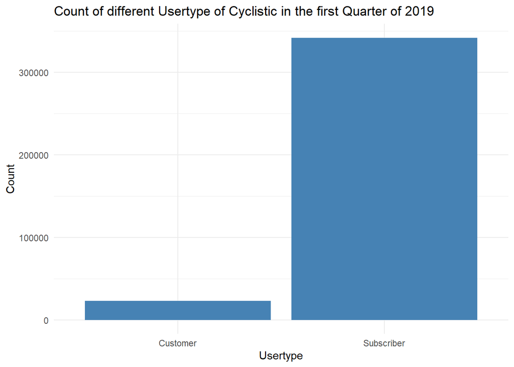

```r
#Checking the usertype column categories of 2019
options(scipen=10000) #displays y-axis as numeric
ggplot(data = trips_2019, aes(x = usertype)) +
  geom_bar(stat="count", fill="steelblue") +
  theme_minimal() +
  labs(title = "Count of different Usertype of Cyclistic in the first Quarter of 2019") + xlab("Usertype") + ylab("Count")
```

The barchart shows that there are more `subscribers` than `customers`. Note: Customers are casual riders while subscribers are annual members

```r
trips_2019 %>%
  group_by(usertype) %>%
  summarize(mean_trip_duration = mean(duration_in_seconds))
```

```
## # A tibble: 2 × 2
##   usertype   mean_trip_duration
##   <chr>                   <dbl>
## 1 Customer                3717.
## 2 Subscriber               834.
```

Although there were more subscribers than customers, the average trip duration of a customer is found to be higher than that of a subscriber.

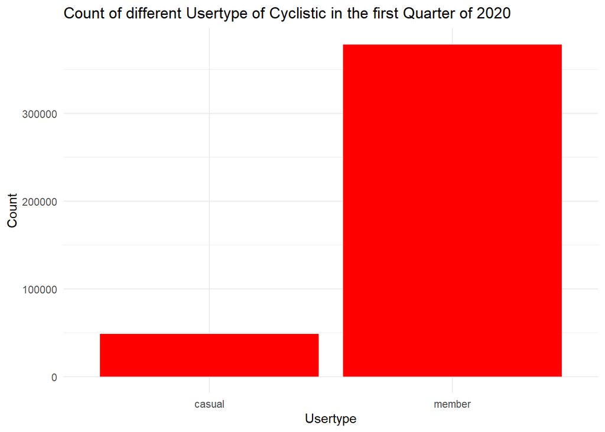

```r
#Checking the usertype column categories of 2019
options(scipen=10000) #displays y-axis as numeric
ggplot(data = trips_2020, aes(x = member_casual)) +
  geom_bar(stat="count", fill="red") +
  theme_minimal() +
  labs(title = "Count of different Usertype of Cyclistic in the first Quarter of 2020") + xlab("Usertype") + ylab("Count")
```

The barchart shows that there are more `members` than `casuals`.

```r
trips_2020 %>%
  group_by(member_casual) %>%
  summarize(mean_trip_duration = mean(duration_in_seconds))
```

```
## # A tibble: 2 × 2
##   member_casual mean_trip_duration
##   <chr>                      <dbl>
## 1 casual                   344818.
## 2 member                    45638.
```

Although there were more members than casual riders, the average trip duration of a casual rider is found to be higher than that of a member.

#### More on the dataset

```r
summary(trips_2019)
```

```
##     trip_id          start_time          end_time             bikeid
##  Min.   :21742443   Length:365069      Length:365069      Min.   :   1
##  1st Qu.:21848765   Class :character   Class :character   1st Qu.:1777
##  Median :21961829   Mode  :character   Mode  :character   Median :3489
##  Mean   :21960872                                         Mean   :3429
##  3rd Qu.:22071823                                         3rd Qu.:5157
##  Max.   :22178528                                         Max.   :6471
##
##  tripduration       from_station_id from_station_name  to_station_id
##  Length:365069      Min.   :  2.0   Length:365069      Min.   :  2.0
##  Class :character   1st Qu.: 76.0   Class :character   1st Qu.: 76.0
##  Mode  :character   Median :170.0   Mode  :character   Median :168.0
##                     Mean   :198.1                      Mean   :198.6
##                     3rd Qu.:287.0                      3rd Qu.:287.0
##                     Max.   :665.0                      Max.   :665.0
##
##  to_station_name      usertype            gender            birthyear
##  Length:365069      Length:365069      Length:365069      Min.   :1900
##  Class :character   Class :character   Class :character   1st Qu.:1975
##  Mode  :character   Mode  :character   Mode  :character   Median :1985
##                                                           Mean   :1982
##                                                           3rd Qu.:1990
##                                                           Max.   :2003
##                                                           NA's   :18023
##  duration_in_seconds
##  Min.   :1M 1S
##  1st Qu.:5M 26S
##  Median :8M 44S
##  Mean   :16M 56.4899923028248S
##  3rd Qu.:14M 26S
##  Max.   :123d 1H 20M 22S
##
```

```r
#Investigating more on the trip duration for 2019 Q1
trips_2019 %>%
  filter(duration_in_seconds == min(duration_in_seconds))
```

```
##     trip_id          start_time            end_time bikeid tripduration
## 1  21743665 2019-01-01 16:02:48 2019-01-01 16:03:49    110         61.0
## 2  21763499 2019-01-05 07:49:03 2019-01-05 07:50:04   5905         61.0
## 3  21794469 2019-01-10 08:10:36 2019-01-10 08:11:37   5468         61.0
## 4  21809886 2019-01-13 19:19:17 2019-01-13 19:20:18   3086         61.0
## 5  21847368 2019-01-22 15:39:49 2019-01-22 15:40:50   2017         61.0
## 6  21862401 2019-01-28 19:06:14 2019-01-28 19:07:15   2274         61.0
## 7  21863790 2019-01-29 17:45:08 2019-01-29 17:46:09   3888         61.0
## 8  21895652 2019-02-07 18:25:40 2019-02-07 18:26:41   4774         61.0
## 9  21895895 2019-02-07 19:05:15 2019-02-07 19:06:16   3376         61.0
## 10 21896140 2019-02-07 20:22:00 2019-02-07 20:23:01   4973         61.0
## 11 21897490 2019-02-08 09:12:24 2019-02-08 09:13:25   1557         61.0
## 12 21913521 2019-02-13 08:01:17 2019-02-13 08:02:18   4395         61.0
## 13 21922915 2019-02-14 17:42:43 2019-02-14 17:43:44   2298         61.0
## 14 21938345 2019-02-19 13:43:41 2019-02-19 13:44:42   1939         61.0
```

[output cut: 109 more lines]

```r
trips_2019 %>%
  filter(duration_in_seconds == max(duration_in_seconds))
```

```
##    trip_id          start_time            end_time bikeid tripduration
## 1 21920842 2019-02-14 14:44:13 2019-06-17 16:04:35   3846 10,628,400.0
##   from_station_id      from_station_name to_station_id
## 1             213 Leavitt St & North Ave           360
##               to_station_name usertype gender birthyear duration_in_seconds
## 1 DIVVY Map Frame B/C Station Customer               NA           10632022S
```

Minimum time duration for trip recorded in the first quarter of 2019 is 61 seconds. Further investigations revealed that majority were subscribers (annual members), while the maximum trip duration recorded in the first quarter of 2019 is 10,632,022 seconds achieved by a customer (casual rider).

```r
summary(trips_2020)
```

```
##    ride_id          rideable_type       started_at          ended_at
##  Length:426887      Length:426887      Length:426887      Length:426887
##  Class :character   Class :character   Class :character   Class :character
##  Mode  :character   Mode  :character   Mode  :character   Mode  :character
##
##
##
##
##  start_station_name start_station_id end_station_name   end_station_id
##  Length:426887      Min.   :  2.0    Length:426887      Min.   :  2.0
##  Class :character   1st Qu.: 77.0    Class :character   1st Qu.: 77.0
##  Mode  :character   Median :176.0    Mode  :character   Median :175.0
##                     Mean   :209.8                       Mean   :209.3
##                     3rd Qu.:298.0                       3rd Qu.:297.0
##                     Max.   :675.0                       Max.   :675.0
##                                                         NA's   :1
##    start_lat       start_lng         end_lat         end_lng
##  Min.   :41.74   Min.   :-87.77   Min.   :41.74   Min.   :-87.77
##  1st Qu.:41.88   1st Qu.:-87.66   1st Qu.:41.88   1st Qu.:-87.66
##  Median :41.89   Median :-87.64   Median :41.89   Median :-87.64
##  Mean   :41.90   Mean   :-87.64   Mean   :41.90   Mean   :-87.64
##  3rd Qu.:41.92   3rd Qu.:-87.63   3rd Qu.:41.92   3rd Qu.:-87.63
##  Max.   :42.06   Max.   :-87.55   Max.   :42.06   Max.   :-87.55
##                                   NA's   :1       NA's   :1
##  member_casual      duration_in_seconds
##  Length:426887      Min.   :-9H -12M 0S
##  Class :character   1st Qu.:5H 29M 0S
##  Mode  :character   Median :9H 10M 0S
##                     Mean   :22H 6M 54.3769194189517S
##                     3rd Qu.:15H 49M 0S
##                     Max.   :6518d 18H 24M 0S
##
```

```r
#Investigating more on the trip duration for 2020 Q1
trips_2020 %>%
  filter(duration_in_seconds == min(duration_in_seconds))
```

```
##            ride_id rideable_type          started_at            ended_at
## 1 6FABADDD595AF922   docked_bike 2020-03-27 15:15:26 2020-03-27 15:06:14
##   start_station_name start_station_id end_station_name end_station_id start_lat
## 1              HQ QR              675            HQ QR            675   41.8899
##   start_lng end_lat  end_lng member_casual duration_in_seconds
## 1  -87.6803 41.8899 -87.6803        casual             -33120S
```

```r
trips_2020 %>%
  filter(duration_in_seconds == max(duration_in_seconds))
```

```
##            ride_id rideable_type          started_at            ended_at
## 1 279F7DB076FD4444   docked_bike 2020-01-09 21:00:22 2020-04-27 12:30:46
##           start_station_name start_station_id         end_station_name
## 1 Stony Island Ave & 75th St              270 South Shore Dr & 67th St
##   end_station_id start_lat start_lng end_lat  end_lng member_casual
## 1            355   41.7587  -87.5869 41.7736 -87.5675        casual
##   duration_in_seconds
## 1          563221440S
```

### Key Findings

- Although there were more members than casual riders, the average trip duration of a casual rider is found to be higher than that of a member for both the first quarters of 2019 and 2020.
- Summary statistics revealed that the casual members recorded the longest trip duration for first quarters 2019 and 2020.